# Econometrics II: Exercise Set 5

Martin-Luther-University Halle-Wittenberg

Chair of Econometrics

2026-01-29

### Problem 2

```r
library(dynlm)
library(ggplot2)
library(lmtest)
library(dplyr)

library("wooldridge")
data(phillips)
```

**2.1 Make yourself familiar with the dataset. Plot the unemployment rate and the inflation rate over time.**

```r
phillips_df <- as.data.frame(phillips)

#Describe dataset
summary(phillips_df)
```

```
##       year           unem            inf             inf_1
##  Min.   :1948   Min.   :2.900   Min.   :-1.200   Min.   :-1.200
##  1st Qu.:1962   1st Qu.:4.500   1st Qu.: 1.675   1st Qu.: 1.650
##  Median :1976   Median :5.550   Median : 3.050   Median : 3.100
##  Mean   :1976   Mean   :5.634   Mean   : 3.884   Mean   : 3.913
##  3rd Qu.:1989   3rd Qu.:6.725   3rd Qu.: 5.425   3rd Qu.: 5.450
##  Max.   :2003   Max.   :9.700   Max.   :13.500   Max.   :13.500
##                                                  NA's   :1
##      unem_1           cinf             cunem
##  Min.   :2.900   Min.   :-9.3000   Min.   :-2.10
##  1st Qu.:4.500   1st Qu.:-1.1500   1st Qu.:-0.60
##  Median :5.500   Median : 0.2000   Median :-0.20
##  Mean   :5.627   Mean   :-0.1055   Mean   : 0.04
##  3rd Qu.:6.750   3rd Qu.: 1.1000   3rd Qu.: 0.60
##  Max.   :9.700   Max.   : 6.6000   Max.   : 2.90
##  NA's   :1       NA's   :1         NA's   :1
```

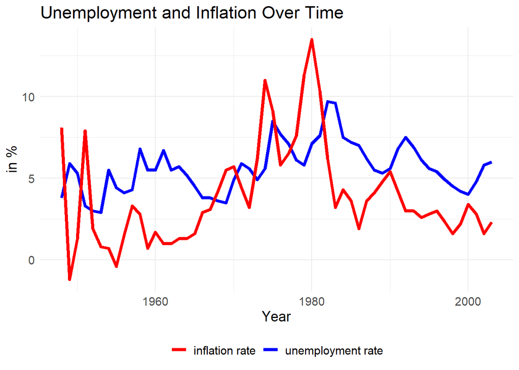

**2.2 Test whether there is a trade-off between unemployment and inflation. Use (i) data up to 1996, (ii) 1997-2003 and (iii) the whole time series. Report your results in a table.**

```r
#Set time series data
tsdata <- ts(phillips, start=1948)

#Static Phillips curve / data until 1996
phil96 <- dynlm( inf ~ unem, data=tsdata, end=1996)
summary(phil96)
```

```
##
## Time series regression with "ts" data:
## Start = 1948, End = 1996
##
## Call:
## dynlm(formula = inf ~ unem, data = tsdata, end = 1996)
##
## Residuals:
##     Min      1Q  Median      3Q     Max
## -5.3826 -1.9797 -0.7229  1.3577  8.7562
##
## Coefficients:
##             Estimate Std. Error t value Pr(>|t|)
## (Intercept)   1.4236     1.7190   0.828    0.412
## unem          0.4676     0.2891   1.617    0.112
##
## Residual standard error: 3.131 on 47 degrees of freedom
## Multiple R-squared:  0.05272,    Adjusted R-squared:  0.03257
## F-statistic: 2.616 on 1 and 47 DF,  p-value: 0.1125
```

```r
#Static Phillips curve / data 1997-2003
phil97 <- dynlm( inf ~ unem, data=tsdata, start=1997)
summary(phil97)
```

```
##
## Time series regression with "ts" data:
## Start = 1997, End = 2003
##
## Call:
## dynlm(formula = inf ~ unem, data = tsdata, start = 1997)
##
## Residuals:
##      1997      1998      1999      2000      2001      2002      2003
## -0.008886 -0.860074 -0.373464  0.750942  0.453317 -0.368714  0.406880
##
## Coefficients:
##             Estimate Std. Error t value Pr(>|t|)
## (Intercept)   4.1609     1.6506   2.521   0.0531 .
## unem         -0.3780     0.3344  -1.130   0.3096
## ---
## Signif. codes:  0 '***' 0.001 '**' 0.01 '*' 0.05 '.' 0.1 ' ' 1
##
## Residual standard error: 0.6245 on 5 degrees of freedom
## Multiple R-squared:  0.2035, Adjusted R-squared:  0.04425
## F-statistic: 1.278 on 1 and 5 DF,  p-value: 0.3096
```

```r
#Static Phillips curve / whole data
phil_all <- dynlm( inf ~ unem, data=tsdata)
summary(phil_all)
```

```
##
## Time series regression with "ts" data:
## Start = 1948, End = 2003
##
## Call:
## dynlm(formula = inf ~ unem, data = tsdata)
##
## Residuals:
##     Min      1Q  Median      3Q     Max
## -5.2176 -1.7812 -0.6659  1.1473  8.8795
##
## Coefficients:
##             Estimate Std. Error t value Pr(>|t|)
## (Intercept)   1.0536     1.5480   0.681   0.4990
## unem          0.5024     0.2656   1.892   0.0639 .
## ---
## Signif. codes:  0 '***' 0.001 '**' 0.01 '*' 0.05 '.' 0.1 ' ' 1
##
## Residual standard error: 2.972 on 54 degrees of freedom
## Multiple R-squared:  0.06215,    Adjusted R-squared:  0.04479
## F-statistic: 3.579 on 1 and 54 DF,  p-value: 0.06389
```

```r
#Stargazer overview
library(stargazer)
stargazer(phil96, phil97, phil_all, type="text")
```

```
##
## ============================================================================
##                                       Dependent variable:
##                     --------------------------------------------------------
##                                               inf
##                            (1)                (2)                (3)
## ----------------------------------------------------------------------------
## unem                      0.468             -0.378             0.502*
##                          (0.289)            (0.334)            (0.266)
##
## Constant                  1.424             4.161*              1.054
##                          (1.719)            (1.651)            (1.548)
##
## ----------------------------------------------------------------------------
## Observations                49                 7                 56
## R2                        0.053              0.204              0.062
## Adjusted R2               0.033              0.044              0.045
## Residual Std. Error  3.131 (df = 47)    0.625 (df = 5)     2.972 (df = 54)
## F Statistic         2.616 (df = 1; 47) 1.278 (df = 1; 5) 3.579* (df = 1; 54)
## ============================================================================
## Note:                                            *p<0.1; **p<0.05; ***p<0.01
```

**2.3 Plot the residuals obtained from the regression and interpret the pattern.**

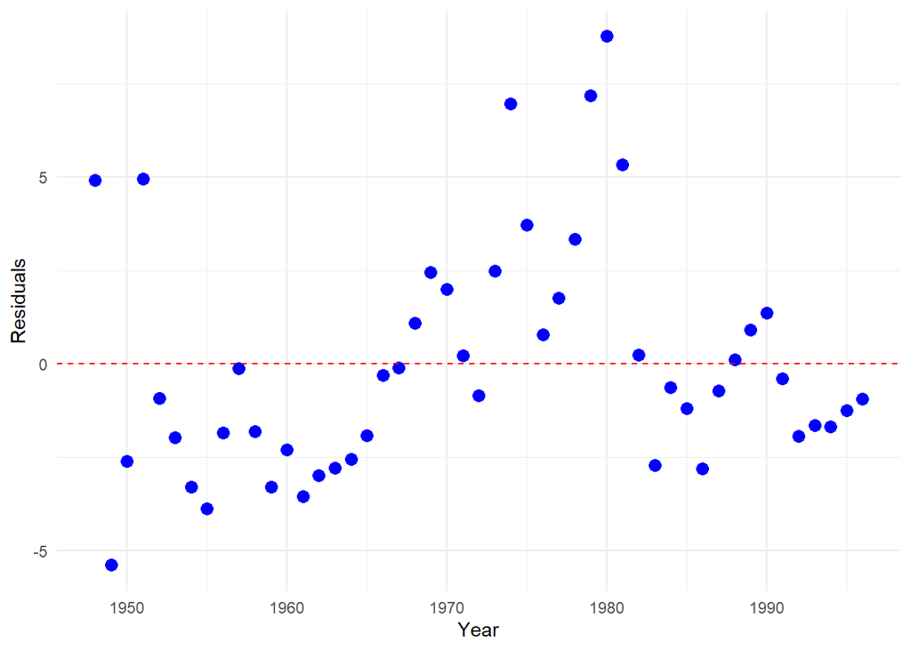

```r
# Residuals (i)
df_res96 <- data.frame( year=seq(1948, 1996, 1),
                  res = resid(phil96) )

ggplot(df_res96, aes(x = year, y = res)) +
  geom_point(size = 3, color = "blue") +
  geom_hline(yintercept = 0, linetype = "dashed", color = "red") +
  labs(x = "Year",
       y = "Residuals") +
  theme_minimal()
```

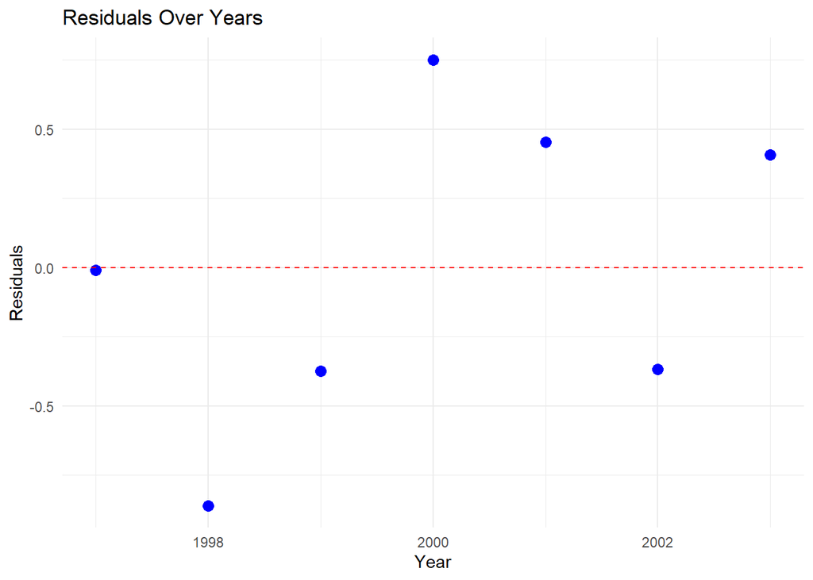

```r
# Residuals (ii)
df_res97 <- data.frame( year=seq(1997, 2003, 1),
                        res = resid(phil97) )

ggplot(df_res97, aes(x = year, y = res)) +
  geom_point(size = 3, color = "blue") +
  geom_hline(yintercept = 0, linetype = "dashed", color = "red") +
  labs(title = "Residuals Over Years",
       x = "Year",
       y = "Residuals") +
  theme_minimal()
```

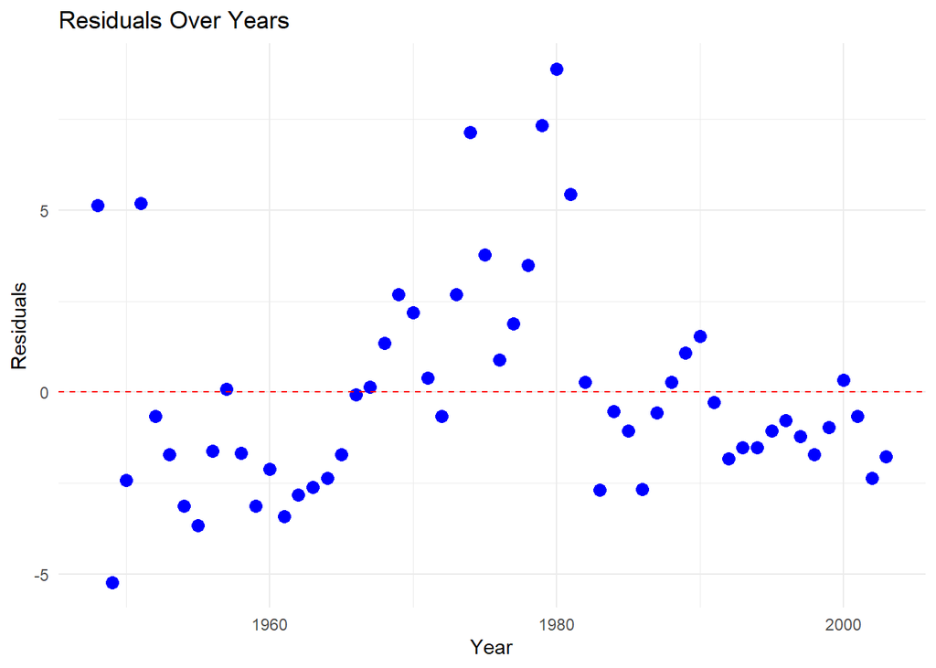

```r
# Residuals (iii)
df_resall <- data.frame( year=seq(1948, 2003, 1),
                        res = resid(phil_all) )

ggplot(df_resall, aes(x = year, y = res)) +
  geom_point(size = 3, color = "blue") +
  geom_hline(yintercept = 0, linetype = "dashed", color = "red") +
  labs(title = "Residuals Over Years",
       x = "Year",
       y = "Residuals") +
  theme_minimal()
```

**2.4 Test for first-order autocorrelation. Carry out a t-test, a Breusch-Godfrey Lagrange multiplier test and a Durbin-Watson test.**

```r
#t-test:
auxreg_all <- dynlm(phil_all$residuals ~ -1 + L(phil_all$residuals))
coeftest(auxreg_all)
```

```
##
## t test of coefficients:
##
##                       Estimate Std. Error t value Pr(>|t|)
## L(phil_all$residuals)  0.57205    0.10747  5.3232 2.02e-06 ***
## ---
## Signif. codes:  0 '***' 0.001 '**' 0.01 '*' 0.05 '.' 0.1 ' ' 1
```

```r
#Breusch-Godfrey-Test
bgtest(phil96)
```

```
##
##  Breusch-Godfrey test for serial correlation of order up to 1
##
## data:  phil96
## LM test = 18.472, df = 1, p-value = 1.725e-05
```

```r
# Durbin-Watson test
dwtest(phil96)
```

```
##
##  Durbin-Watson test
##
## data:  phil96
## DW = 0.8027, p-value = 7.552e-07
## alternative hypothesis: true autocorrelation is greater than 0
```

**2.5 Use the entire data set. Estimate the Phillips curve model by iterative Cochrane-Orcutt and Prais-Winsten.**

```r
phil_all <- dynlm( inf ~ unem, data=tsdata)
summary(phil_all)
```

```
##
## Time series regression with "ts" data:
## Start = 1948, End = 2003
##
## Call:
## dynlm(formula = inf ~ unem, data = tsdata)
##
## Residuals:
##     Min      1Q  Median      3Q     Max
## -5.2176 -1.7812 -0.6659  1.1473  8.8795
##
## Coefficients:
##             Estimate Std. Error t value Pr(>|t|)
## (Intercept)   1.0536     1.5480   0.681   0.4990
## unem          0.5024     0.2656   1.892   0.0639 .
## ---
## Signif. codes:  0 '***' 0.001 '**' 0.01 '*' 0.05 '.' 0.1 ' ' 1
##
## Residual standard error: 2.972 on 54 degrees of freedom
## Multiple R-squared:  0.06215,    Adjusted R-squared:  0.04479
## F-statistic: 3.579 on 1 and 54 DF,  p-value: 0.06389
```

```r
#Orcutt
library(orcutt)
co <- cochrane.orcutt(phil_all)
cochrane.orcutt(phil_all)
```

```
## Cochrane-orcutt estimation for first order autocorrelation
##
## Call:
## dynlm(formula = inf ~ unem, data = tsdata)
##
##  number of interaction: 12
##  rho 0.782009
##
## Durbin-Watson statistic
## (original):    0.80148 , p-value: 1.486e-07
## (transformed): 1.60020 , p-value: 6.435e-02
##
##  coefficients:
## (Intercept)        unem
##    7.287079   -0.663959
```

```r
summary(co)
```

```
## Call:
## dynlm(formula = inf ~ unem, data = tsdata)
##
##             Estimate Std. Error t value Pr(>|t|)
## (Intercept)  7.28708    2.16318   3.369 0.001414 **
## unem        -0.66396    0.29420  -2.257 0.028168 *
## ---
## Signif. codes:  0 '***' 0.001 '**' 0.01 '*' 0.05 '.' 0.1 ' ' 1
##
## Residual standard error: 2.1428 on 53 degrees of freedom
## Multiple R-squared:  0.0877 ,  Adjusted R-squared:  0.0705
## F-statistic: 5.1 on 1 and 53 DF,  p-value: < 2.817e-02
##
## Durbin-Watson statistic
## (original):    0.80148 , p-value: 1.486e-07
## (transformed): 1.60020 , p-value: 6.435e-02
```

```r
#PRAIS:
library(prais)
pw <- prais_winsten(inf ~ unem, data=tsdata, index="year")
```

```
## Iteration 0: rho = 0
## Iteration 1: rho = 0.5721
## Iteration 2: rho = 0.735
## Iteration 3: rho = 0.7792
## Iteration 4: rho = 0.7871
## Iteration 5: rho = 0.7883
## Iteration 6: rho = 0.7885
## Iteration 7: rho = 0.7885
## Iteration 8: rho = 0.7885
## Iteration 9: rho = 0.7885
```

```r
summary(pw)
```

```
##
## Call:
## prais_winsten(formula = inf ~ unem, data = tsdata, index = "year")
##
## Residuals:
##    Min     1Q Median     3Q    Max
## -5.258 -2.447 -1.073  1.463 10.570
##
## AR(1) coefficient rho after 9 iterations: 0.7885
##
## Coefficients:
##             Estimate Std. Error t value Pr(>|t|)
## (Intercept)   7.9994     2.0483   3.905 0.000264 ***
## unem         -0.7140     0.2898  -2.464 0.016965 *
## ---
## Signif. codes:  0 '***' 0.001 '**' 0.01 '*' 0.05 '.' 0.1 ' ' 1
##
## Residual standard error: 2.138 on 54 degrees of freedom
## Multiple R-squared:  0.1345, Adjusted R-squared:  0.1185
## F-statistic: 8.393 on 1 and 54 DF,  p-value: 0.00543
##
## Durbin-Watson statistic (original): 0.8015
## Durbin-Watson statistic (transformed): 1.914
```

```r
#compare rho
pw$rho
```

```
##         rho
## 0 0.0000000
## 1 0.5720550
## 2 0.7350489
## 3 0.7792428
## 4 0.7870990
## 5 0.7883098
## 6 0.7884915
## 7 0.7885187
## 8 0.7885228
## 9 0.7885234
```

```r
co$rho
```

```
## [1] 0.7820094
```

```r
dynlm(phil_all$residuals ~ -1 + L(phil_all$residuals)) #ols
```

```
##
## Time series regression with "ts" data:
## Start = 1949, End = 2003
##
## Call:
## dynlm(formula = phil_all$residuals ~ -1 + L(phil_all$residuals))
##
## Coefficients:
## L(phil_all$residuals)
##                0.5721
```

**2.6 Include inflationary expectations into your model. Assume adaptive expectations, i.e. the expected value of current inflation depends on recently observed inflation. Estimate the following model: Δin ft = β0 + β1unempt +et . Test for first-order autocorrelation.**

```r
#Expectations augmented Phillips curve: Simple formulation of expected inflation: last year's inflation
phil.ea <- dynlm(d(inf) ~ unem, data=tsdata)
summary(phil.ea)
```

```
##
## Time series regression with "ts" data:
## Start = 1949, End = 2003
##
## Call:
## dynlm(formula = d(inf) ~ unem, data = tsdata)
##
## Residuals:
##     Min      1Q  Median      3Q     Max
## -9.0741 -0.9241  0.0189  0.8606  5.4800
##
## Coefficients:
##             Estimate Std. Error t value Pr(>|t|)
## (Intercept)   2.8282     1.2249   2.309   0.0249 *
## unem         -0.5176     0.2090  -2.476   0.0165 *
## ---
## Signif. codes:  0 '***' 0.001 '**' 0.01 '*' 0.05 '.' 0.1 ' ' 1
##
## Residual standard error: 2.307 on 53 degrees of freedom
## Multiple R-squared:  0.1037, Adjusted R-squared:  0.08679
## F-statistic: 6.132 on 1 and 53 DF,  p-value: 0.0165
```

```r
#t-test:
aux.ea <- dynlm(phil.ea$residuals ~ -1 + L(phil.ea$residuals))
coeftest(aux.ea)
```

```
##
## t test of coefficients:
##
##                       Estimate Std. Error t value Pr(>|t|)
## L(phil.ea$residuals) -0.033279   0.115691 -0.2877   0.7747
```

```r
#Breusch-Godfrey-Test
bgtest(phil.ea)
```

```
##
##  Breusch-Godfrey test for serial correlation of order up to 1
##
## data:  phil.ea
## LM test = 0.061273, df = 1, p-value = 0.8045
```

```r
# Durbin-Watson test
dwtest(phil.ea)
```

```
##
##  Durbin-Watson test
##
## data:  phil.ea
## DW = 1.771, p-value = 0.1673
## alternative hypothesis: true autocorrelation is greater than 0
```

**2.7 Estimate a Phillips curve model where inflation and unemployment are in first differences.**

```r
phil.ea2 <- dynlm( d(inf) ~ d(unem), data=tsdata)
summary(phil.ea2)
```

```
##
## Time series regression with "ts" data:
## Start = 1949, End = 2003
##
## Call:
## dynlm(formula = d(inf) ~ d(unem), data = tsdata)
##
## Residuals:
##     Min      1Q  Median      3Q     Max
## -7.4790 -0.9441  0.1384  1.0889  5.4551
##
## Coefficients:
##             Estimate Std. Error t value Pr(>|t|)
## (Intercept) -0.07214    0.30584  -0.236  0.81443
## d(unem)     -0.83281    0.28984  -2.873  0.00583 **
## ---
## Signif. codes:  0 '***' 0.001 '**' 0.01 '*' 0.05 '.' 0.1 ' ' 1
##
## Residual standard error: 2.267 on 53 degrees of freedom
## Multiple R-squared:  0.1348, Adjusted R-squared:  0.1185
## F-statistic: 8.256 on 1 and 53 DF,  p-value: 0.005831
```

```r
#Breusch-Godfrey-Test
bgtest(phil.ea2)
```

```
##
##  Breusch-Godfrey test for serial correlation of order up to 1
##
## data:  phil.ea2
## LM test = 0.037232, df = 1, p-value = 0.847
```

### Problem 5

**5.1 Produce a graph of the natural logarithm of quarterly income.**

```r
# Import data into R
library(haven)
data <- read_dta(file = "YOURPATH/income.dta")
```

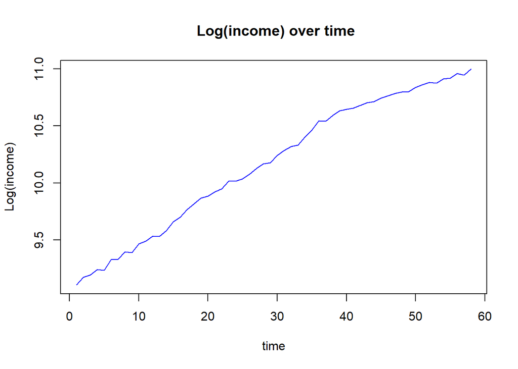

```r
# Log-transformation:
data$loginc <- log(data$income)

#Set data as time-series data:
tsd <- ts(data, start=1)

#Plot:
plot(data$time, data$loginc, type="l", main=" Log(income) over time", xlab="time" ,
     ylab="Log(income)", col="blue")
```

**5.2 Perform augmented Dickey-Fuller tests including 1 up to 6 lags, with and without including a linear trend. What do you conclude about the presence of a unit root in log income?**

```r
library("dynlm")

#Standard Dickey-Fuller regression (intercept, log(income)
library(urca)

summary( ur.df(data$loginc, type = "drift", lags=1) )
```

```
##
## ###############################################
## # Augmented Dickey-Fuller Test Unit Root Test #
## ###############################################
##
## Test regression drift
##
##
## Call:
## lm(formula = z.diff ~ z.lag.1 + 1 + z.diff.lag)
##
## Residuals:
##       Min        1Q    Median        3Q       Max
## -0.049131 -0.014720 -0.004651  0.016032  0.064785
##
## Coefficients:
##              Estimate Std. Error t value Pr(>|t|)
## (Intercept)  0.216969   0.059541   3.644 0.000612 ***
## z.lag.1     -0.016874   0.005715  -2.953 0.004688 **
## z.diff.lag  -0.386109   0.125592  -3.074 0.003331 **
## ---
## Signif. codes:  0 '***' 0.001 '**' 0.01 '*' 0.05 '.' 0.1 ' ' 1
##
## Residual standard error: 0.02315 on 53 degrees of freedom
## Multiple R-squared:  0.2109, Adjusted R-squared:  0.1812
## F-statistic: 7.085 on 2 and 53 DF,  p-value: 0.001876
##
##
## Value of test-statistic is: -2.9526 38.974
##
## Critical values for test statistics:
##       1pct  5pct 10pct
## tau2 -3.51 -2.89 -2.58
## phi1  6.70  4.71  3.86
```

```r
#without trend
ur.df(data$loginc, type="drift", lags=1)
```

```
##
## ###############################################################
## # Augmented Dickey-Fuller Test Unit Root / Cointegration Test #
## ###############################################################
##
## The value of the test statistic is: -2.9526 38.974
```

```r
summary(ur.df(data$loginc, type="drift", lags=2))
```

```
##
## ###############################################
## # Augmented Dickey-Fuller Test Unit Root Test #
## ###############################################
##
## Test regression drift
##
##
## Call:
## lm(formula = z.diff ~ z.lag.1 + 1 + z.diff.lag)
##
## Residuals:
##       Min        1Q    Median        3Q       Max
## -0.044438 -0.014047 -0.001746  0.013750  0.052356
##
## Coefficients:
##              Estimate Std. Error t value Pr(>|t|)
## (Intercept)  0.175014   0.066065   2.649   0.0107 *
## z.lag.1     -0.013837   0.006136  -2.255   0.0284 *
## z.diff.lag1 -0.288992   0.133514  -2.165   0.0351 *
## z.diff.lag2  0.242086   0.135980   1.780   0.0810 .
## ---
## Signif. codes:  0 '***' 0.001 '**' 0.01 '*' 0.05 '.' 0.1 ' ' 1
##
## Residual standard error: 0.02278 on 51 degrees of freedom
## Multiple R-squared:  0.2609, Adjusted R-squared:  0.2174
## F-statistic: 6.002 on 3 and 51 DF,  p-value: 0.001392
##
##
## Value of test-statistic is: -2.2553 9.3372
##
## Critical values for test statistics:
##       1pct  5pct 10pct
## tau2 -3.51 -2.89 -2.58
## phi1  6.70  4.71  3.86
```

```r
ur.df(data$loginc, type="drift", lags=3)
```

```
##
## ###############################################################
## # Augmented Dickey-Fuller Test Unit Root / Cointegration Test #
## ###############################################################
##
## The value of the test statistic is: -2.7231 10.9631
```

```r
ur.df(data$loginc, type="drift", lags=4)
```

```
##
## ###############################################################
## # Augmented Dickey-Fuller Test Unit Root / Cointegration Test #
## ###############################################################
##
## The value of the test statistic is: -2.3663 4.535
```

```r
ur.df(data$loginc, type="drift", lags=5)
```

```
##
## ###############################################################
## # Augmented Dickey-Fuller Test Unit Root / Cointegration Test #
## ###############################################################
##
## The value of the test statistic is: -1.69 2.3605
```

```r
summary(ur.df(data$loginc, type="drift", lags=6))
```

```
##
## ###############################################
## # Augmented Dickey-Fuller Test Unit Root Test #
## ###############################################
##
## Test regression drift
##
##
## Call:
## lm(formula = z.diff ~ z.lag.1 + 1 + z.diff.lag)
##
## Residuals:
##      Min       1Q   Median       3Q      Max
## -0.03283 -0.01242 -0.00398  0.01280  0.04998
##
## Coefficients:
##              Estimate Std. Error t value Pr(>|t|)
## (Intercept)  0.182718   0.074219   2.462  0.01791 *
## z.lag.1     -0.014832   0.006608  -2.244  0.03001 *
## z.diff.lag1 -0.089146   0.141320  -0.631  0.53150
## z.diff.lag2  0.217806   0.139991   1.556  0.12707
## z.diff.lag3 -0.210477   0.125738  -1.674  0.10140
## z.diff.lag4  0.409861   0.124376   3.295  0.00197 **
## z.diff.lag5  0.052825   0.134546   0.393  0.69654
## z.diff.lag6 -0.313636   0.133974  -2.341  0.02394 *
## ---
## Signif. codes:  0 '***' 0.001 '**' 0.01 '*' 0.05 '.' 0.1 ' ' 1
##
## Residual standard error: 0.01924 on 43 degrees of freedom
## Multiple R-squared:  0.4585, Adjusted R-squared:  0.3703
## F-statistic:   5.2 on 7 and 43 DF,  p-value: 0.0002387
##
##
## Value of test-statistic is: -2.2443 4.4915
##
## Critical values for test statistics:
##       1pct  5pct 10pct
## tau2 -3.51 -2.89 -2.58
## phi1  6.70  4.71  3.86
```

```r
#With trend
summary(ur.df(data$loginc, type="trend", lags=1))
```

```
##
## ###############################################
## # Augmented Dickey-Fuller Test Unit Root Test #
## ###############################################
##
## Test regression trend
##
##
## Call:
## lm(formula = z.diff ~ z.lag.1 + 1 + tt + z.diff.lag)
##
## Residuals:
##       Min        1Q    Median        3Q       Max
## -0.047285 -0.015135 -0.003753  0.016732  0.062099
##
## Coefficients:
##              Estimate Std. Error t value Pr(>|t|)
## (Intercept) -0.196682   0.414689  -0.474  0.63728
## z.lag.1      0.028637   0.045512   0.629  0.53197
## tt          -0.001624   0.001611  -1.008  0.31815
## z.diff.lag  -0.435301   0.134724  -3.231  0.00214 **
## ---
## Signif. codes:  0 '***' 0.001 '**' 0.01 '*' 0.05 '.' 0.1 ' ' 1
##
## Residual standard error: 0.02315 on 52 degrees of freedom
## Multiple R-squared:  0.2261, Adjusted R-squared:  0.1814
## F-statistic: 5.063 on 3 and 52 DF,  p-value: 0.003757
##
##
## Value of test-statistic is: 0.6292 26.3291 4.8683
##
## Critical values for test statistics:
##       1pct  5pct 10pct
## tau3 -4.04 -3.45 -3.15
## phi2  6.50  4.88  4.16
## phi3  8.73  6.49  5.47
```

```r
ur.df(data$loginc, type="trend", lags=2)
```

```
##
## ###############################################################
## # Augmented Dickey-Fuller Test Unit Root / Cointegration Test #
## ###############################################################
##
## The value of the test statistic is: 0.0398 6.1526 2.5535
```

```r
ur.df(data$loginc, type="trend", lags=3)
```

```
##
## ###############################################################
## # Augmented Dickey-Fuller Test Unit Root / Cointegration Test #
## ###############################################################
##
## The value of the test statistic is: 0.6159 7.6169 4.1775
```

```r
ur.df(data$loginc, type="trend", lags=4)
```

```
##
## ###############################################################
## # Augmented Dickey-Fuller Test Unit Root / Cointegration Test #
## ###############################################################
##
## The value of the test statistic is: -0.6021 2.9957 2.7918
```

```r
ur.df(data$loginc, type="trend", lags=5)
```

```
##
## ###############################################################
## # Augmented Dickey-Fuller Test Unit Root / Cointegration Test #
## ###############################################################
##
## The value of the test statistic is: -0.8298 1.681 1.6019
```

```r
summary(ur.df(data$loginc, type="trend", lags=6))
```

```
##
## ###############################################
## # Augmented Dickey-Fuller Test Unit Root Test #
## ###############################################
##
## Test regression trend
##
##
## Call:
## lm(formula = z.diff ~ z.lag.1 + 1 + tt + z.diff.lag)
##
## Residuals:
##       Min        1Q    Median        3Q       Max
## -0.032791 -0.012211 -0.003963  0.012350  0.049885
##
## Coefficients:
##               Estimate Std. Error t value Pr(>|t|)
## (Intercept)  0.0742884  0.4907663   0.151  0.88041
## z.lag.1     -0.0025789  0.0552111  -0.047  0.96297
## tt          -0.0004585  0.0020507  -0.224  0.82418
## z.diff.lag1 -0.1001769  0.1511857  -0.663  0.51120
## z.diff.lag2  0.2074368  0.1489678   1.392  0.17110
## z.diff.lag3 -0.2271612  0.1474320  -1.541  0.13087
## z.diff.lag4  0.3954539  0.1413209   2.798  0.00772 **
## z.diff.lag5  0.0366924  0.1540076   0.238  0.81285
## z.diff.lag6 -0.3268756  0.1478557  -2.211  0.03255 *
## ---
## Signif. codes:  0 '***' 0.001 '**' 0.01 '*' 0.05 '.' 0.1 ' ' 1
##
## Residual standard error: 0.01945 on 42 degrees of freedom
## Multiple R-squared:  0.4591, Adjusted R-squared:  0.3561
## F-statistic: 4.456 on 8 and 42 DF,  p-value: 0.0005735
##
##
## Value of test-statistic is: -0.0467 2.9448 2.4878
##
## Critical values for test statistics:
##       1pct  5pct 10pct
## tau3 -4.04 -3.45 -3.15
## phi2  6.50  4.88  4.16
## phi3  8.73  6.49  5.47
```

**5.3 Transform the series into first differences and produce a graph. Perform augmented Dickey-Fuller tests on the change in log income including 1 up to 6 lags. What do you conclude? Motivate why you did or did not include a time trend.**

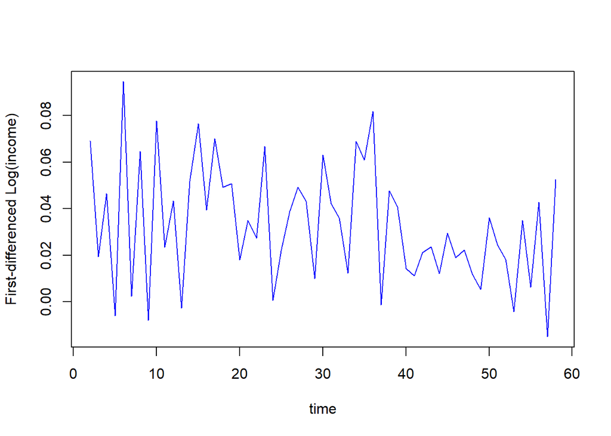

```r
fd <- data.frame(time=2:58)
fd$d_loginc <- diff(data$loginc, differences=1)
tsd <- ts(fd, start=2)
tsd <- ts(fd$d_loginc, start = 2)
plot(fd$time, fd$d_loginc, type="l", xlab="time" , ylab="First-differenced Log(income)", col="blue")
```

```r
library(urca)
adf<- ur.df(fd$d_loginc, type="drift", lags=1)
urca::summary(adf)
```

```
##
## ###############################################
## # Augmented Dickey-Fuller Test Unit Root Test #
## ###############################################
##
## Test regression drift
##
##
## Call:
## lm(formula = z.diff ~ z.lag.1 + 1 + z.diff.lag)
##
## Residuals:
##       Min        1Q    Median        3Q       Max
## -0.036304 -0.017741 -0.003234  0.014843  0.060076
##
## Coefficients:
##              Estimate Std. Error t value Pr(>|t|)
## (Intercept)  0.026932   0.007588   3.549 0.000829 ***
## z.lag.1     -0.834599   0.208831  -3.997 0.000204 ***
## z.diff.lag  -0.350816   0.132049  -2.657 0.010454 *
## ---
## Signif. codes:  0 '***' 0.001 '**' 0.01 '*' 0.05 '.' 0.1 ' ' 1
##
## Residual standard error: 0.02366 on 52 degrees of freedom
## Multiple R-squared:  0.6808, Adjusted R-squared:  0.6685
## F-statistic: 55.45 on 2 and 52 DF,  p-value: 1.276e-13
##
##
## Value of test-statistic is: -3.9965 8.0025
##
## Critical values for test statistics:
##       1pct  5pct 10pct
## tau2 -3.51 -2.89 -2.58
## phi1  6.70  4.71  3.86
```

```r
summary(ur.df(fd$d_loginc, type="drift", lags=2))
```

```
##
## ###############################################
## # Augmented Dickey-Fuller Test Unit Root Test #
## ###############################################
##
## Test regression drift
##
##
## Call:
## lm(formula = z.diff ~ z.lag.1 + 1 + z.diff.lag)
##
## Residuals:
##       Min        1Q    Median        3Q       Max
## -0.037206 -0.018348 -0.002389  0.016064  0.059639
##
## Coefficients:
##              Estimate Std. Error t value Pr(>|t|)
## (Intercept)  0.031047   0.008657   3.586 0.000761 ***
## z.lag.1     -0.955306   0.242923  -3.933 0.000259 ***
## z.diff.lag1 -0.180388   0.215329  -0.838 0.406169
## z.diff.lag2  0.145759   0.142113   1.026 0.309990
## ---
## Signif. codes:  0 '***' 0.001 '**' 0.01 '*' 0.05 '.' 0.1 ' ' 1
##
## Residual standard error: 0.02388 on 50 degrees of freedom
## Multiple R-squared:  0.6849, Adjusted R-squared:  0.666
## F-statistic: 36.23 on 3 and 50 DF,  p-value: 1.38e-12
##
##
## Value of test-statistic is: -3.9325 7.7445
##
## Critical values for test statistics:
##       1pct  5pct 10pct
## tau2 -3.51 -2.89 -2.58
## phi1  6.70  4.71  3.86
```

```r
summary(ur.df(fd$d_loginc, type="drift", lags=3))
```

```
##
## ###############################################
## # Augmented Dickey-Fuller Test Unit Root Test #
## ###############################################
##
## Test regression drift
##
##
## Call:
## lm(formula = z.diff ~ z.lag.1 + 1 + z.diff.lag)
##
## Residuals:
##       Min        1Q    Median        3Q       Max
## -0.044967 -0.011670 -0.007133  0.011833  0.056598
##
## Coefficients:
##              Estimate Std. Error t value Pr(>|t|)
## (Intercept)  0.015652   0.008795   1.780 0.081471 .
## z.lag.1     -0.484934   0.250379  -1.937 0.058668 .
## z.diff.lag1 -0.587244   0.220309  -2.666 0.010441 *
## z.diff.lag2 -0.406224   0.193916  -2.095 0.041487 *
## z.diff.lag3 -0.463320   0.128376  -3.609 0.000732 ***
## ---
## Signif. codes:  0 '***' 0.001 '**' 0.01 '*' 0.05 '.' 0.1 ' ' 1
##
## Residual standard error: 0.02132 on 48 degrees of freedom
## Multiple R-squared:  0.7512, Adjusted R-squared:  0.7304
## F-statistic: 36.22 on 4 and 48 DF,  p-value: 6.049e-14
##
##
## Value of test-statistic is: -1.9368 1.8853
##
## Critical values for test statistics:
##       1pct  5pct 10pct
## tau2 -3.51 -2.89 -2.58
## phi1  6.70  4.71  3.86
```

```r
summary(ur.df(fd$d_loginc, type="drift", lags=4))
```

```
##
## ###############################################
## # Augmented Dickey-Fuller Test Unit Root Test #
## ###############################################
##
## Test regression drift
##
##
## Call:
## lm(formula = z.diff ~ z.lag.1 + 1 + z.diff.lag)
##
## Residuals:
##      Min       1Q   Median       3Q      Max
## -0.04791 -0.01368 -0.00634  0.01165  0.05234
##
## Coefficients:
##              Estimate Std. Error t value Pr(>|t|)
## (Intercept)  0.012029   0.008985   1.339  0.18721
## z.lag.1     -0.402221   0.255615  -1.574  0.12245
## z.diff.lag1 -0.696091   0.258987  -2.688  0.00998 **
## z.diff.lag2 -0.495351   0.230544  -2.149  0.03696 *
## z.diff.lag3 -0.581311   0.198011  -2.936  0.00518 **
## z.diff.lag4 -0.143549   0.141335  -1.016  0.31510
## ---
## Signif. codes:  0 '***' 0.001 '**' 0.01 '*' 0.05 '.' 0.1 ' ' 1
##
## Residual standard error: 0.0207 on 46 degrees of freedom
## Multiple R-squared:  0.746,  Adjusted R-squared:  0.7184
## F-statistic: 27.02 on 5 and 46 DF,  p-value: 1.208e-12
##
##
## Value of test-statistic is: -1.5735 1.351
##
## Critical values for test statistics:
##       1pct  5pct 10pct
## tau2 -3.51 -2.89 -2.58
## phi1  6.70  4.71  3.86
```

```r
summary(ur.df(fd$d_loginc, type="drift", lags=5))
```

```
##
## ###############################################
## # Augmented Dickey-Fuller Test Unit Root Test #
## ###############################################
##
## Test regression drift
##
##
## Call:
## lm(formula = z.diff ~ z.lag.1 + 1 + z.diff.lag)
##
## Residuals:
##       Min        1Q    Median        3Q       Max
## -0.043259 -0.013222 -0.002331  0.011525  0.045366
##
## Coefficients:
##              Estimate Std. Error t value Pr(>|t|)
## (Intercept)  0.017296   0.009098   1.901   0.0638 .
## z.lag.1     -0.538656   0.258689  -2.082   0.0432 *
## z.diff.lag1 -0.483007   0.269851  -1.790   0.0804 .
## z.diff.lag2 -0.168280   0.273460  -0.615   0.5415
## z.diff.lag3 -0.298219   0.237458  -1.256   0.2158
## z.diff.lag4  0.188408   0.211682   0.890   0.3783
## z.diff.lag5  0.286892   0.139430   2.058   0.0456 *
## ---
## Signif. codes:  0 '***' 0.001 '**' 0.01 '*' 0.05 '.' 0.1 ' ' 1
##
## Residual standard error: 0.0201 on 44 degrees of freedom
## Multiple R-squared:  0.7426, Adjusted R-squared:  0.7075
## F-statistic: 21.16 on 6 and 44 DF,  p-value: 1.688e-11
##
##
## Value of test-statistic is: -2.0823 2.1991
##
## Critical values for test statistics:
##       1pct  5pct 10pct
## tau2 -3.51 -2.89 -2.58
## phi1  6.70  4.71  3.86
```

```r
summary(ur.df(fd$d_loginc, type="drift", lags=6))
```

```
##
## ###############################################
## # Augmented Dickey-Fuller Test Unit Root Test #
## ###############################################
##
## Test regression drift
##
##
## Call:
## lm(formula = z.diff ~ z.lag.1 + 1 + z.diff.lag)
##
## Residuals:
##       Min        1Q    Median        3Q       Max
## -0.042355 -0.011797 -0.001373  0.011533  0.043906
##
## Coefficients:
##             Estimate Std. Error t value Pr(>|t|)
## (Intercept)  0.01577    0.00991   1.591   0.1191
## z.lag.1     -0.50302    0.28176  -1.785   0.0814 .
## z.diff.lag1 -0.48883    0.28171  -1.735   0.0900 .
## z.diff.lag2 -0.20913    0.28818  -0.726   0.4721
## z.diff.lag3 -0.36038    0.28452  -1.267   0.2123
## z.diff.lag4  0.14405    0.25028   0.576   0.5680
## z.diff.lag5  0.21581    0.21996   0.981   0.3321
## z.diff.lag6 -0.06490    0.14964  -0.434   0.6667
## ---
## Signif. codes:  0 '***' 0.001 '**' 0.01 '*' 0.05 '.' 0.1 ' ' 1
##
## Residual standard error: 0.02043 on 42 degrees of freedom
## Multiple R-squared:  0.7315, Adjusted R-squared:  0.6868
## F-statistic: 16.35 on 7 and 42 DF,  p-value: 3.603e-10
##
##
## Value of test-statistic is: -1.7853 1.6714
##
## Critical values for test statistics:
##       1pct  5pct 10pct
## tau2 -3.51 -2.89 -2.58
## phi1  6.70  4.71  3.86
```

**5.4 Determine the sample ACF and PACF for the change in log income. Is there an obvious model suggested by these graphs?**

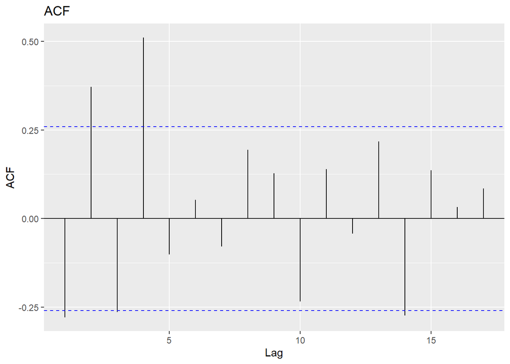

```r
library(forecast)
library(ggplot2)
ggAcf(fd$d_loginc) + ggtitle("ACF")
```

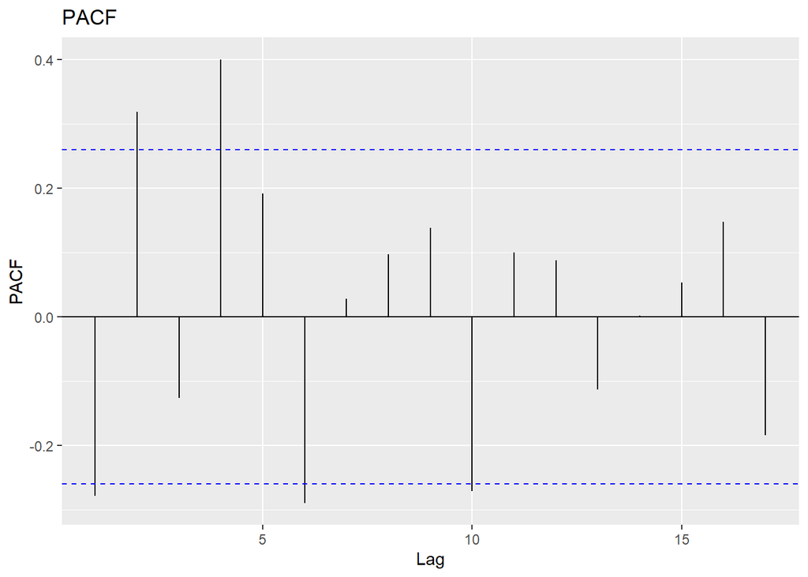

```r
ggPacf(fd$d_loginc) + ggtitle ("PACF")
```

**5.5 Estimate an ARIMA(4,1,4) model for the change in log income.**

```r
arima414 <- forecast::Arima(fd$d_loginc, order = c(4,1,4),include.constant = TRUE)
arima414
```

```
## Series: fd$d_loginc
## ARIMA(4,1,4) with drift
##
## Coefficients:
##           ar1      ar2      ar3     ar4      ma1     ma2      ma3      ma4
##       -0.2716  -0.4640  -0.2795  0.5268  -0.8789  0.8817  -0.9702  -0.0326
## s.e.   0.2179   0.1573   0.2146  0.1578   0.2498  0.2406   0.2611   0.2566
##        drift
##       -4e-04
## s.e.   2e-04
##
## sigma^2 = 0.0003143:  log likelihood = 145.79
## AIC=-271.58   AICc=-266.69   BIC=-251.32
```

**5.6 Test for serial correlation in the residuals of the model. Can you reject the null hypothesis of white noise errors?**

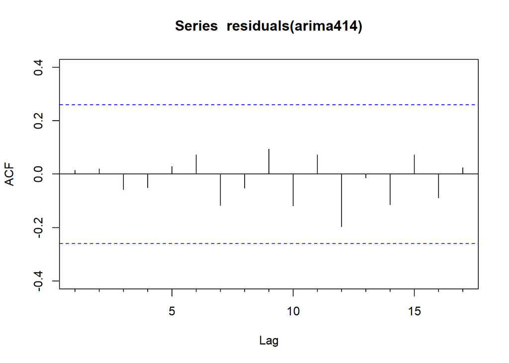

```r
Acf(residuals(arima414))# acf
```

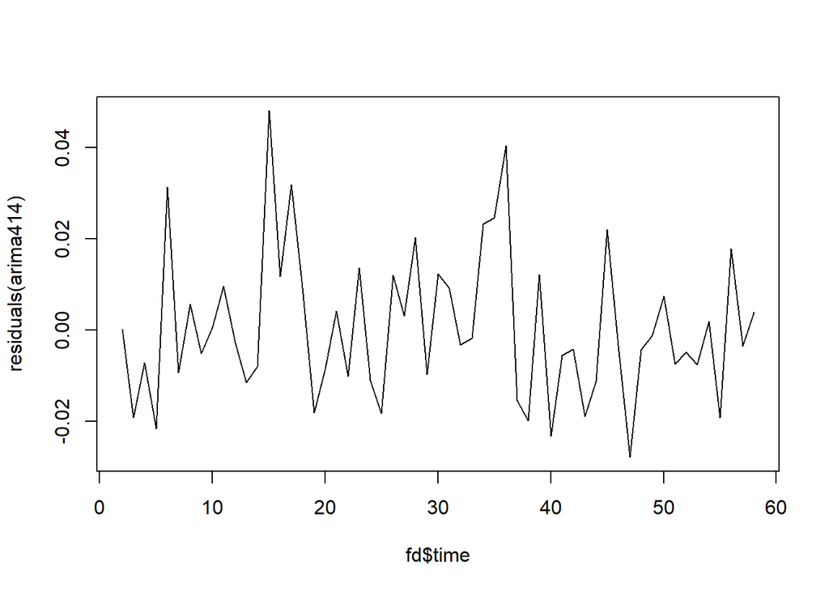

```r
plot(fd$time,residuals(arima414), type="l")
```

```r
#Ljung-box test
library(stats)
Box.test(residuals(arima414),type="Ljung",lag=12,fitdf=1)
```

```
##
##  Box-Ljung test
##
## data:  residuals(arima414)
## X-squared = 6.7983, df = 11, p-value = 0.8152
```